# Partie YouTube

## Importation des librairies

```python
from bs4 import BeautifulSoup as bs
import requests
import pytube
import time
from selenium.webdriver import Chrome
from contextlib import closing
from selenium.webdriver.chrome.options import Options
from selenium.webdriver.support.ui import WebDriverWait
from selenium.webdriver.common.by import By
from selenium.webdriver.support import expected_conditions as EC
from selenium.webdriver.common.keys import Keys
import sys
from selenium import webdriver
import pandas as pd
import numpy as np
from sklearn.model_selection import train_test_split
import nltk
from nltk.corpus import stopwords
from nltk.classify import SklearnClassifier
from wordcloud import WordCloud,STOPWORDS
import matplotlib.pyplot as plt
%matplotlib inline
from subprocess import check_output
from textblob import TextBlob
import nltk
nltk.download('punkt')
```

## Récupération des liens

Nous allons récupérer les liens disponibles sur Youtube en relation avec la phrase clé "Donald Trump"

```python
base = "https://www.youtube.com/results?search_query="
qstring = "donald trump"
r = requests.get(base+qstring)
page = r.text
soup=bs(page,'html.parser')
vids = soup.findAll('a',attrs={'class':'yt-uix-tile-link'})
videolist=[]
for v in vids:
    tmp = 'https://www.youtube.com' + v['href']
    videolist.append(tmp)
```

Visualisation des liens

```python
for item in videolist:
    print(item)
```

```
https://www.youtube.com/watch?v=4pxg-3Fde-A
https://www.youtube.com/watch?v=hN5yJjrCpOE
https://www.youtube.com/watch?v=mpPaAUFNdNk
https://www.youtube.com/watch?v=XU3AbY9E5_8
https://www.youtube.com/watch?v=CO3WgtllgzU
https://www.youtube.com/watch?v=Lw_L-2AjSvQ
https://www.youtube.com/watch?v=EZe_EYYZVnQ
https://www.youtube.com/watch?v=lh26sMxlf2k
https://www.youtube.com/watch?v=Js4yi4G5QTk
https://www.youtube.com/watch?v=iEtXjuSJcLg
https://www.youtube.com/watch?v=DU6BnuyjJqI
https://www.youtube.com/watch?v=PaLoko8Ut20
https://www.youtube.com/watch?v=Ce7CyUchpzg
https://www.youtube.com/watch?v=mohpw8epS8w
https://www.youtube.com/watch?v=qZAiHuQ-kv0
https://www.youtube.com/watch?v=JUu86wySweI
https://www.youtube.com/watch?v=y61Z0gLrOx4
https://www.youtube.com/watch?v=55L60jkk-nE
https://www.youtube.com/watch?v=tP4bYz_wEJc
https://www.youtube.com/watch?v=No6oT29p7sc
```

## Récuperation des commentaires

```python
chrome_options = Options()
chrome_options.add_argument("--headless")
ListComs=[]
ListDesId=[]
MyList=[]
for i in range(len(ListComs)):
    ListDesId.append(i)
with closing(Chrome(chrome_options=chrome_options)) as driver:

    for i in range(len(videolist)):

        wait = WebDriverWait(driver,10)
        MyList.append(videolist[i])
        driver.get(videolist[i])
        for item in range(3):
            wait.until(EC.visibility_of_element_located((By.TAG_NAME, "body"))).send_keys(Keys.END)
            time.sleep(3)

        for comment in wait.until(EC.presence_of_all_elements_located((By.CSS_SELECTOR, "#comment #content-text"))):
            ListComs.append(comment.text)
            print(comment.text)
```

[output not shown]

[output cut: 25 more lines]

```
El Chapo Pelosi is a Cartel funded spokesperson, she doesn't want anything that won't line her pockets.
I hope President Trump utilized the red line veto to cross out the ICE bed restrictions and the other pork put in the bill to protect the illegals who are crooks! If thy passed all that was in the bill, I will be very disappointed in The President in signing the bill.
Don't sign that bill... it's full of amnesty loopholes and accompanied children assuring entry for whole families.....bad deal
"Sit down"! 😂😂😂 Like a boss! Oh... he is the boss!
Shakespearean plot and Master's direction...proud of your work, Trump!
40 or more years of tons of empty promises for a tall, strong wall.  Nothing done until President Trump came to office.  We all have seen the pictures. Dems and RINOS are always using their fear tactics.
How great is President Trump...….He is for the people...…….FU Democrats
Thank you for doing the national emergency declaration and THANK YOU for explaining everything.
🙏🙏🙏 Don't SIGN President; God bless America & our elected President Trump. Bring evildoers to JUSTICE.
Love that President Trump tells it like it is.  Of course, the msm tries their grandest to scare voters.  That he's breaking the law and all.
We need more death penalty here too.
$8 billion is not even close to enough.
A fully funded wall is step one.
We need immigration reform!
... democrats will undo everything, it has to be comprehensive and permanent!
```

Les commentaires sont stockés dans un fichier CSV

```python
data=pd.DataFrame()
data['Id']=ListDesId
data['comments']=ListComs
data.to_csv('Youtube.csv',index = False,encoding='utf-8')
```

## Analyse Sentimentale

Dans cette étape on va voir quels sont les commentaires positifs et quels sont les commentaires négatifs

```python
polarity=0.0
i=0
neutral=0
positive=0
negative=0
listPos=[]
listNeg=[]
PosPolarity=0.0
NegPolarity=0.0
with open('Youtube.csv', encoding="utf8") as f:
    for s in f:
        blob = TextBlob(s)
        for sentence in blob.sentences:
            i=i+1
            polarity=polarity+sentence.sentiment.polarity
            if sentence.sentiment.polarity<0:
                print("\033[1m"+"negative sentiment"+"\033[0;0m")
                print(sentence)
                print(sentence.sentiment.polarity)
                negative=negative+1
                NegPolarity=NegPolarity+sentence.sentiment.polarity
                listNeg.append(sentence)
            if sentence.sentiment.polarity>0:
                print("\033[1m"+"positive sentiment"+"\033[0;0m")
                print(sentence)
                print(sentence.sentiment.polarity)
                positive=positive+1
                PosPolarity=PosPolarity+sentence.sentiment.polarity
                listPos.append(sentence)
            if sentence.sentiment.polarity==0:
                print("\033[1m"+"neutral sentiment"+"\033[0;0m")
                print(sentence)
                print(sentence.sentiment.polarity)
                neutral=neutral+1
```

```
neutral sentiment
Id,comments
0.0
neutral sentiment
0,"""spinning in a Tasmanian devil style rage"" 😂😂😂😂"
0.0
neutral sentiment
1,18 minutes to wipe his arse.
0.0
neutral sentiment
2,Putin is a homie hopper.
0.0



neutral sentiment
Everything."
0.0
neutral sentiment
74,"The failing Trump Crime Family,"
0.0
negative sentiment
75,"Reap what you sow, miserable clown."
-1.0
positive sentiment
76,"Trump's mood is going to get more sour when the Dems take over the House!
0.15625
negative sentiment
Poor baby!
-0.5
negative sentiment
FYI to our people in the military and our vets, remember how your president disrespected your service to the country this Veterans Day!
-0.125
neutral sentiment
DISGRACE!"
0.0
neutral sentiment
77,"Makes me think Trump shoved Melania forward to fire the National Security Aide.
0.0
positive sentiment
```

[output cut: 62 more lines]

```
neutral sentiment
How can you retreat when you’re already an REMF?
0.0
neutral sentiment
(Rear Echelon Mo-Fo.
0.0
positive sentiment
You know, the guy with the BEST war stories.
1.0
neutral sentiment
While he rides a desk, or a mop.)"
0.0
neutral sentiment
88,All I hear is Wahhhh!🤣😂
0.0
```

Séparer les commentaires positifs et négatifs dans 2 fichiers CSV diffèrents

```python
datapos=pd.DataFrame()
datapos['comments']=listPos
datapos.to_csv('YoutubePositive.csv',index = False,encoding='utf-8')
dataneg=pd.DataFrame()
dataneg['comments']=listNeg
dataneg.to_csv('YoutubeNegative.csv',index = False,encoding='utf-8')
```

```python
MydataPos=pd.read_csv('YoutubePositive.csv')
MydataNeg=pd.read_csv('YoutubeNegative.csv')
```

## Traitement automatique du langage naturel

Il s'agit de visualiser les mots qui reviennent dans les commentaires et qui caractérisent une réactions positive ou négative au contenu de la vidéo

```
Positive words
```

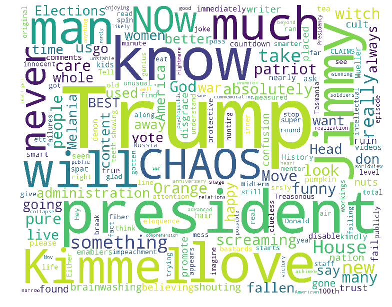

```
Negative words
```

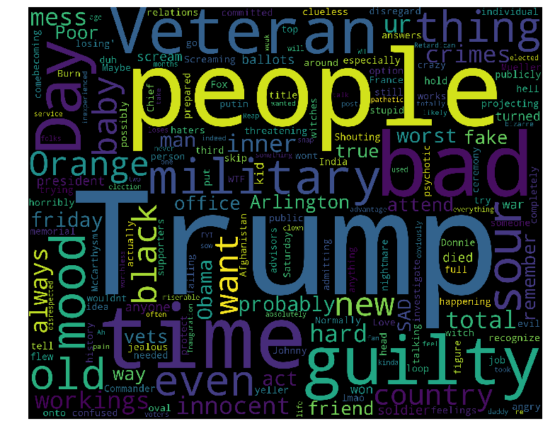

```python
def wordcloud_draw(data, color = 'black'):
    words = ' '.join(data)
    cleaned_word = " ".join([word for word in words.split()
                            if 'http' not in word
                                and not word.startswith('@')
                                and not word.startswith('#')
                                and word != 'RT'
                            ])
    wordcloud = WordCloud(stopwords=STOPWORDS,
                      background_color=color,
                      width=2500,
                      height=2000
                     ).generate(cleaned_word)
    plt.figure(1,figsize=(13, 13))
    plt.imshow(wordcloud)
    plt.axis('off')
    plt.show()

print("Positive words")
wordcloud_draw(MydataPos['comments'],'white')
print("Negative words")
wordcloud_draw(MydataNeg['comments'])
```

## Récupération des descriptions des vidéos

```python
desc=[]
for item in videolist:
    s = requests.Session()
    r = s.get(item)
    html = r.text
    soup = bs(html, 'lxml')
    for i in soup.find_all('p', id='eow-description'):
        for br in i.find_all('br'):
            next_sib = br.next_sibling
            desc.append(next_sib)
desc
```

```
['» Subscribe to MSNBC: ',
 <br/>,
 'About: MSNBC is the premier destination for in-depth analysis of daily headlines, insightful political commentary and informed perspectives. Reaching more than 95 million households worldwide, MSNBC offers a full schedule of live news coverage, political opinions and award-winning documentary prog…
 <br/>,
 'Connect with MSNBC Online',
 'Visit msnbc.com: ',
 'Subscribe to MSNBC Newsletter: MSNBC.com/NewslettersYouTube',
 'Find MSNBC on Facebook: ',
 'Follow MSNBC on Twitter: ',
 'Follow MSNBC on Instagram: ',
 <br/>,
 'Donald Trump And Chief Justice Go Head-To-Head Over Judicial Independence | The 11th Hour | MSNBC',
 '» Subscribe to MSNBC: ',
 <br/>,
 'About: MSNBC is the premier destination for in-depth analysis of daily headlines, insightful political commentary and informed perspectives. Reaching more than 95 million households worldwide, MSNBC offers a full schedule of live news coverage, political opinions and award-winning documentary prog…
 <br/>,
 'Connect with MSNBC Online',
 'Visit msnbc.com: ',
 'Subscribe to MSNBC Newsletter: MSNBC.com/NewslettersYouTube',
 'Find MSNBC on Facebook: ',
 'Follow MSNBC on Twitter: ',
 'Follow MSNBC on Instagram: ',
 <br/>,
 "Joe: We're Seeing Worst Of President Donald Trump After Midterms | Morning Joe | MSNBC",
 '» Subscribe to MSNBC: ',
 <br/>,
 'About: MSNBC is the premier destination for in-depth analysis of daily headlines, insightful political commentary and informed perspectives. Reaching more than 95 million households worldwide, MSNBC offers a full schedule of live news coverage, political opinions and award-winning documentary prog…
 <br/>,
 'Connect with MSNBC Online',
 'Visit msnbc.com: ',
 'Subscribe to MSNBC Newsletter: MSNBC.com/NewslettersYouTube',
 'Find MSNBC on Facebook: ',
```

Stockage des descriptions dans un fichier CSV

```python
dataDesc=pd.DataFrame()
dataDesc['text']=desc
dataDesc.to_csv('Descriptions.csv',index = False,encoding='utf-8')
```

Calcul des polarités(positifs/négatifs) des descriptions des vidéos

```python
polarity=0.0
i=0
neutral=0
positive2=0
negative2=0
PosPolarity2=0.0
NegPolarity2=0.0
with open('Descriptions.csv', encoding="utf8") as f:
    for s in f:
        blob = TextBlob(s)
        for sentence in blob.sentences:
            i=i+1
            polarity=polarity+sentence.sentiment.polarity
            if sentence.sentiment.polarity<0:

                negative2=negative2+1
                NegPolarity2=NegPolarity2+sentence.sentiment.polarity

            if sentence.sentiment.polarity>0:

                positive2=positive2+1
                PosPolarity2=PosPolarity2+sentence.sentiment.polarity

            if sentence.sentiment.polarity==0:

                neutral=neutral+1
```

## Comparaison des polarités entre les commentaires et les descriptions des vidéos

Moyenne de la polarité positive des commentaires

```python
MoyPosPolarity=PosPolarity/positive
MoyPosPolarity
```

```
0.12857932641673203
```

Moyenne de la polarité négative des commentaires

```python
MoyNegPolarity=NegPolarity/negative
MoyNegPolarity
```

[output not shown]

Moyenne de la polarité positive des descriptions

```python
MoyPosPolarity2=PosPolarity2/positive2
MoyPosPolarity2
```

```
0.28225626324030584
```

Moyenne de la polarité négative des descriptions

```python
MoyNegPolarity2=NegPolarity2/negative2
MoyNegPolarity2
```

```
-0.3885416666666666
```

#### Interprétations

On remarque que la moyenne de la polartité positive dans les descriptions est largement supérieure à celle des commentaires. On remarque que la moyenne de la polartité négative dans les descriptions est largement supérieure à celle des commentaires. On peut donc dire que les commentaires et les descriptions ne sont pas proportionnelles et vu que les moyennes des descriptions sont élevés on peut émettre une hypothèse sur le fait que les descriptions des vidéos sont exagérées dans le bon ou le mauvais sens